# IMF Online Course: Macroeconomic forecasting

## Module 3A: Statistical Properties of Time Series Data

### Identification of Stationary Processes

**Author**: Miha Trošt  
**Date**: 29-01-2016

```r
# useful libraries
library(plyr)
library(dplyr)
library(forecast)
library(stringr)
library(lubridate)
library(tidyr)
library(broom)
```

```r
my_wd <-
  "C:/Users/Miha/Documents/GitHub/IMF_Macro_Forecasting_R/002_module_3a_Statistical_properties_of_time_series/Module3_data/"

m3_data <-
  read.csv(str_c(my_wd, "module3_data_Identifying_ARMA.csv"),
           sep = ",")

my_df <-
  read.csv(str_c(my_wd, "module3_data_PE_Ratios.csv"),
           sep = ",",
           stringsAsFactors = FALSE)
```

#### QUESTION 3.19

Suppose you have estimated three MA models for a given series Z, and have obtained the following results:

MA(1): R<sup>2</sup> = 0.852

MA(2): R<sup>2</sup> = 0.854

MA(3): R<sup>2</sup> = 0.855

Indicate which of the following could explain why the MA(3) is not the best model for Z (select all that apply):

1. Although the MA(3) has the best fit, it does not have the lowest AIC.
2. Not all of the three MA(3) coefficients are statistically significant.

### Comparing Models

Consider the following three models that have been estimated for pe_ind (the stock market price-earnings ratio in India).

**Model 1** is an AR(1); **Model 2** has AR terms at lags 1 and 8 only; **Model 3** has AR terms at lags 1 and 8, and an MA term at lag 8.

For each model, the regression results and the ACF, PACF and Q-Statistics for the residuals are estimated:

```r
my_pe_ind <-
  my_df %>%
  select(date, pe_ind) %>%
  filter(complete.cases(.)) %>%
  mutate(date = as.Date(date))

# my time series
my_ts <- my_pe_ind$pe_ind

# Model 1
model_1 <-
  Arima(my_ts, order = c(1, 0, 0))

# Model 2
my_ar_terms <- c(NA, rep(0, 6), NA)
my_ma_terms <- c(rep(0, 7), NA)
my_intercept <- NA

my_terms_mod_2 <-
  c(my_ar_terms, my_intercept)

model_2 <-
  Arima(my_ts, order = c(8, 0, 0), fixed = my_terms_mod_2)

# Model 3
my_terms_mod_3 <-
  c(my_ar_terms, my_ma_terms, my_intercept)

model_3 <-
  Arima(my_ts, order = c(8, 0, 8), fixed = my_terms_mod_3)
```

#### QUESTION 3.20

Which model has the lowest Sum of Squared Residuals (SSR)?

```r
min_ssr <-
  which.min(c(sum(resid(model_1) ^ 2),
              sum(resid(model_2) ^ 2),
              sum(resid(model_3) ^ 2)))
```

The lowest SSR has the model number 3.

#### QUESTION 3.21

Which model has the lowest Akaike Information Criterion (AIC)?

```r
min_aic <-
  which.min(c(AIC(model_1), AIC(model_2), AIC(model_3)))
```

#### QUESTION 3.22

Which model has the lowest Schwarz’s Bayesian criterion (SBC or BIC)?

```r
min_bic <-
  which.min(c(BIC(model_1), BIC(model_2), BIC(model_3)))
```

#### QUESTION 3.23

With which model or models can you be reasonably confident that the residuals are not serially correlated?

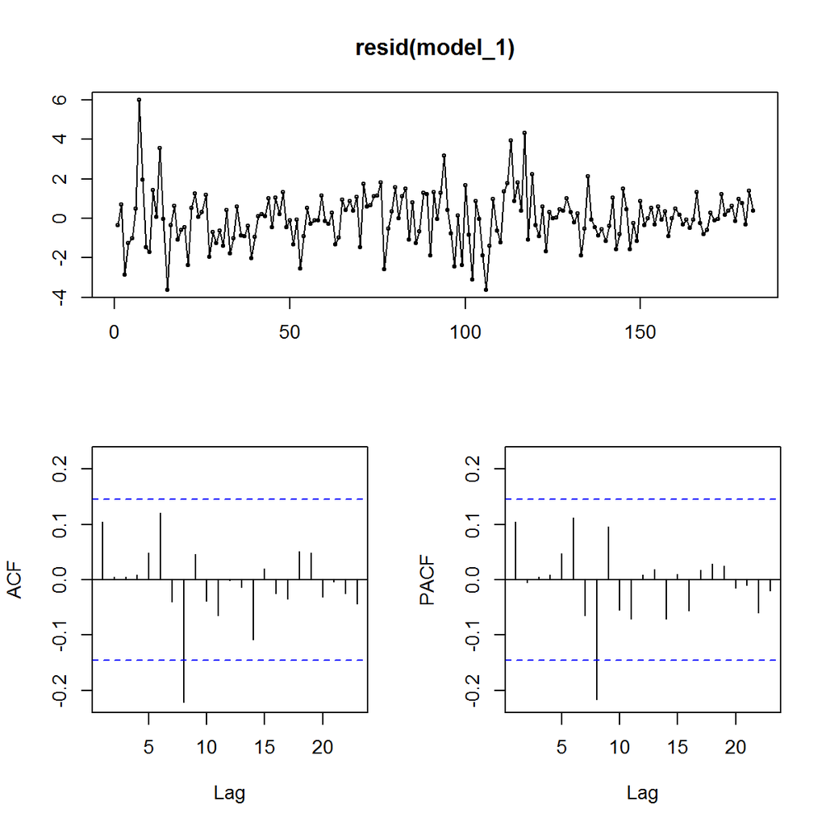

```r
tsdisplay(resid(model_1))
```

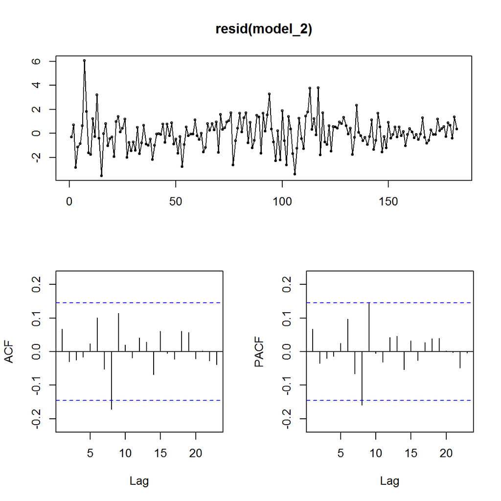

```r
tsdisplay(resid(model_2))
```

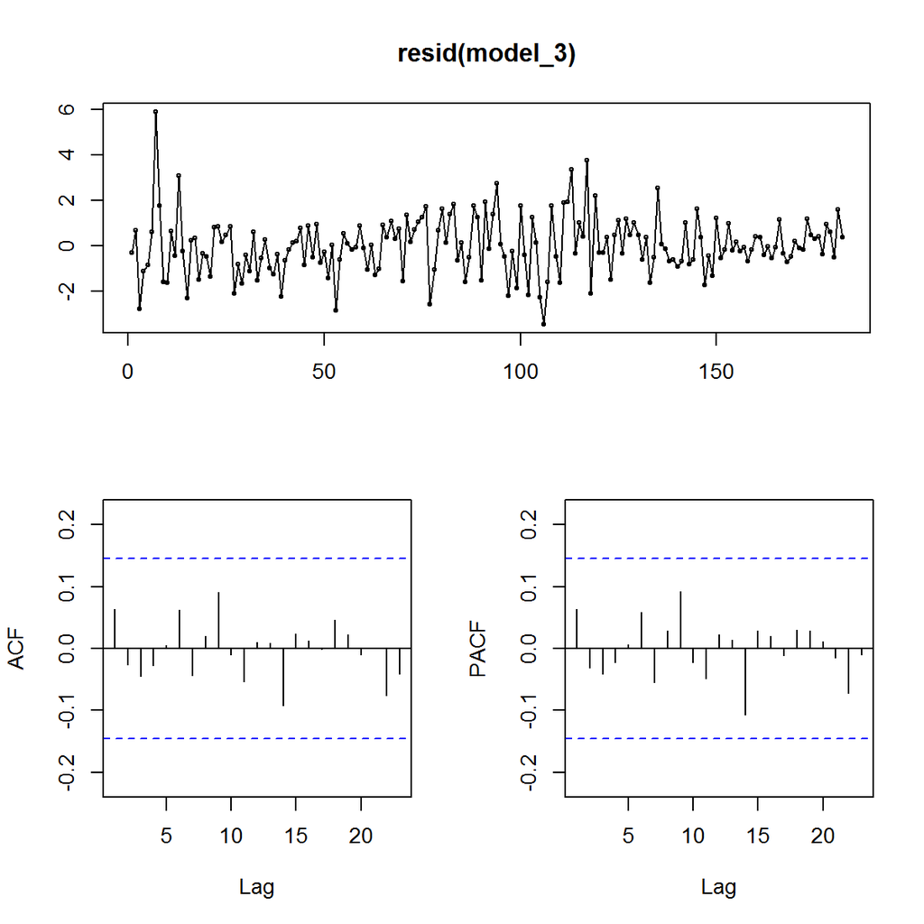

```r
tsdisplay(resid(model_3))
```

#### QUESTION 3.24

Based on your reading of the results, what will you do now to determine the best model for pe_ind?

Run one more model that might outperform all three models.